# Portafolio de trabajos Estadistica NRC 1271

## 3

Los siguientes valores representan las calificaciones de $32$ estudiantes que se presentaron a un examen de Estadística.
$$55, 70, 80, 75, 90,
80, 60, 100, 95, 70, 75, 85, 80, 80, 70, 95,$$
$$100, 80, 85, 70, 85, 90, 80, 75, 85, 70, 90, 60,
80, 70, 85, 80$$

```r
# Cargar los datos
calificaciones <- c(55, 70, 80, 75, 90, 80, 60, 100, 95, 70, 75, 85, 80, 80, 70, 95,
                   100, 80, 85, 70, 85, 90, 80, 75, 85, 70, 90, 60, 80, 70, 85, 80)

# Crear la tabla de frecuencias
frecuencias <- table(calificaciones)
freq_table <- data.frame(Calificación = names(frecuencias), Frecuencia = as.numeric(frecuencias))
freq_table <- freq_table[order(as.numeric(freq_table$Calificación)), ]

# Imprimir la tabla de frecuencias
knitr::kable(freq_table, caption = "Tabla de Frecuencias")
```

Tabla de Frecuencias

| Calificación | Frecuencia |
| --- | --- |
| 55 | 1 |
| 60 | 2 |
| 70 | 6 |
| 75 | 3 |
| 80 | 8 |
| 85 | 5 |
| 90 | 3 |
| 95 | 2 |
| 100 | 2 |

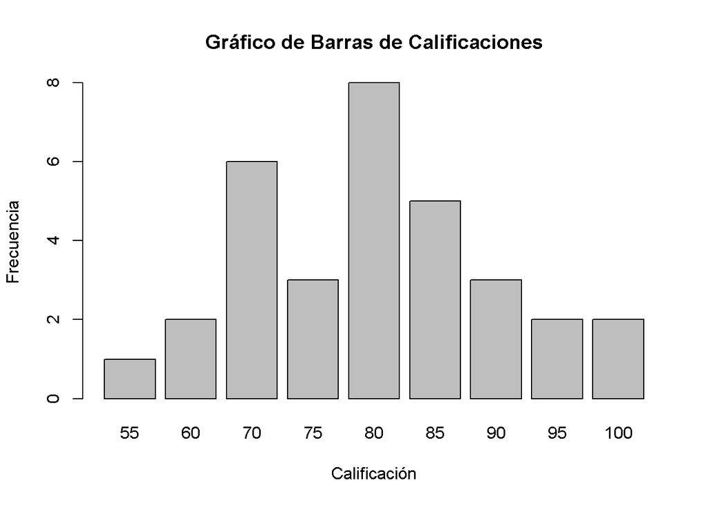

```r
# Crear el gráfico de barras
barplot(freq_table$Frecuencia, names.arg = freq_table$Calificación,
        main = "Gráfico de Barras de Calificaciones",
        xlab = "Calificación", ylab = "Frecuencia")
```

## 4 La siguiente es una clasilicación de la población de Estados Unidos por edad y sexo. Los números que aparecen en cada una de las clases están en unidades de millón.

$$\begin{array}{|c|c|c|}
\hline
\textbf{Edad} & \textbf{Mujeres} & \textbf{Hombres} \\ \hline
\text{Hasta 25 años} & 48,8 & 50,4 \\ \hline
\text{Más de 25 años} & 74,5 & 66,6 \\ \hline
\end{array}$$
Supongamos que se elige a una persona aleatoriamente. Si A es el suceso de que la persona sea varón y B eI suceso de que su edad no sobrepase los 25 años. encuentre:

```r
# Datos
poblacion <- data.frame(
  Edad = c("Hasta 25 años", "Más de 25 años"),
  Mujeres = c(48.8, 74.5),
  Hombres = c(50.4, 66.6)
)

# (a) P(A) y P(AC)
p_a <- poblacion$Hombres[2] / (poblacion$Hombres[1] + poblacion$Hombres[2])
p_ac <- 1 - p_a
cat("P(A) =", p_a, "\nP(AC) =", p_ac, "\n")
```

```
## P(A) = 0.5692308
## P(AC) = 0.4307692
```

```r
# (b) P(B) y P(B')
p_b <- poblacion$Hombres[1] / (poblacion$Hombres[1] + poblacion$Hombres[2])
p_b_prima <- 1 - p_b
cat("P(B) =", p_b, "\nP(B') =", p_b_prima, "\n")
```

```
## P(B) = 0.4307692
## P(B') = 0.5692308
```

```r
# (c) P(A|B)
p_a_b <- poblacion$Hombres[1] / (poblacion$Hombres[1] + poblacion$Mujeres[1])
cat("P(A|B) =", p_a_b, "\n")
```

```
## P(A|B) = 0.5080645
```

```r
# (f) P(B|A)
p_b_a <- poblacion$Hombres[1] / (poblacion$Hombres[1] + poblacion$Hombres[2])
cat("P(B|A) =", p_b_a, "\n")
```

```
## P(B|A) = 0.4307692
```

## 7

```r
# Datos
mu <- 4.5 # Valor esperado
sigma2 <- 0.45 # Varianza

# (a) P(X = 3)
p_x_3 <- dbinom(3, size = mu / sigma2, prob = 1 / (mu / sigma2))
cat("P(X = 3) =", p_x_3, "\n")
```

```
## P(X = 3) = 0.05739563
```

```r
# (b) P(X > 4)
p_x_gt_4 <- 1 - pbinom(4, size = mu / sigma2, prob = 1 / (mu / sigma2))
cat("P(X > 4) =", p_x_gt_4, "\n")
```

```
## P(X > 4) = 0.001634937
```

## 8

Si $X$ es de una variable aleatoria de Poisson con media 4, calcule:

```r
# Datos
lambda <- 4 # Media de la distribución de Poisson

# (a) P(X = 1)
p_x_1 <- dpois(1, lambda)
cat("P(X = 1) =", p_x_1, "\n")
```

```
## P(X = 1) = 0.07326256
```

```r
# (b) P(X = 2)
p_x_2 <- dpois(2, lambda)
cat("P(X = 2) =", p_x_2, "\n")
```

```
## P(X = 2) = 0.1465251
```

```r
# (c) P(X > 2)
p_x_gt_2 <- 1 - ppois(2, lambda)
cat("P(X > 2) =", p_x_gt_2, "\n")
```

```
## P(X > 2) = 0.7618967
```

## 9

EI tiempo de vida de un fusible en cierta aplicación tiene distribución exponencial con media de dos años.

```r
# Datos
lambda <- 1/2 # Media de la distribución exponencial (1/μ)

# (a) Valor del parámetro λ
k <- lambda
cat("El valor del parámetro λ es:", k, "\n")
```

```
## El valor del parámetro λ es: 0.5
```

```r
# (b) Mediana del tiempo de vida
mediana <- log(2) / lambda
cat("La mediana del tiempo de vida es:", mediana, "años\n")
```

```
## La mediana del tiempo de vida es: 1.386294 años
```

```r
# (c) Desviación estándar
desv_est <- 1 / lambda
cat("La desviación estándar es:", desv_est, "años\n")
```

```
## La desviación estándar es: 2 años
```

```r
# (d) Percentil 600
percentil_600 <- qexp(0.6, rate = lambda)
cat("El percentil 600 es:", percentil_600, "años\n")
```

```
## El percentil 600 es: 1.832581 años
```

```r
# (e) Probabilidad de que un fusible dure más de 5 años
p_mas_5_anos <- 1 - pexp(5, rate = lambda)
cat("La probabilidad de que un fusible dure más de 5 años es:", p_mas_5_anos, "\n")
```

```
## La probabilidad de que un fusible dure más de 5 años es: 0.082085
```

```r
# (f) Probabilidad de que funcione 2 años más si lleva 1 año
p_2_anos_mas <- pexp(2, rate = lambda) / (1 - pexp(1, rate = lambda))
cat("La probabilidad de que funcione 2 años más si lleva 1 año es:", p_2_anos_mas, "\n")
```

[output not shown]

## 10

Suponga que la estatura de mujeres en una población sigue la curva normal con media de $64.3$ pulgadas y desviación estándar de $2.6$ pulgadas,

```r
# Datos
media <- 64.3 # Media de la estatura en pulgadas
desv_est <- 2.6 # Desviación estándar de la estatura en pulgadas

# (a) Proporción de mujeres con estatura entre 60 y 66 pulgadas
p_60_66 <- pnorm(66, mean = media, sd = desv_est) - pnorm(60, mean = media, sd = desv_est)
cat("La proporción de mujeres con estatura entre 60 y 66 pulgadas es:", p_60_66, "\n")
```

```
## La proporción de mujeres con estatura entre 60 y 66 pulgadas es: 0.6943151
```

```r
# (b) Proporción de mujeres con estatura mayor a 0.5 desviaciones estándar por encima de la media
estatura_0.5_desv <- media + 0.5 * desv_est
p_mayor_0.5_desv <- 1 - pnorm(estatura_0.5_desv, mean = media, sd = desv_est)
cat("La proporción de mujeres con estatura mayor a 0.5 desviaciones estándar por encima de la media es:", p_mayor_0.5_desv, "\n")
```

```
## La proporción de mujeres con estatura mayor a 0.5 desviaciones estándar por encima de la media es: 0.3085375
```

```r
# (c) Estatura de la mujer en el percentil 90
estatura_90_percentil <- qnorm(0.9, mean = media, sd = desv_est)
cat("La estatura de la mujer en el percentil 90 es:", estatura_90_percentil, "pulgadas\n")
```

```
## La estatura de la mujer en el percentil 90 es: 67.63203 pulgadas
```

# Resumen de fórmulas

| Nombre | Fórmula | Descripción |
| --- | --- | --- |
| Varianza | $\text{Var}(X) = \frac{\sum_{i=1}^{n} (X_i - \bar{X})^2}{n}$ | Medida de dispersión de una variable aleatoria. |
| Desviación Estándar | $\sigma = \sqrt{\text{Var}(X)}$ | Raíz cuadrada de la varianza, mide la dispersión en la misma unidad que los datos. |
| Probabilidad | $P(A) = \frac{N(A)}{N}$ | Proporción de eventos favorables al total de eventos posibles. |
| Unión de Eventos | $P(A \cup B) = P(A) + P(B) - P(A \cap B)$ | Probabilidad de la unión de dos eventos. |
| Regla del Producto | $P(A \cap B) = P(A) \cdot P(B)$ | Probabilidad de la intersección de dos eventos independientes. |
| Permutación | $P(n, r) = \frac{n!}{(n-r)!}$ | Número de maneras de ordenar r elementos de un conjunto de n. |
| Combinación | $C(n, r) = \frac{n!}{r!(n-r)!}$ | Número de maneras de elegir r elementos de un conjunto de n sin importar el orden. |
| Prob. Eventos Independientes | $P(A \cap B) = P(A) \cdot P(B)$ | Para eventos independientes, la probabilidad conjunta es el producto de las probabilidades individuales. |
| Eventos Equiprobables | $P(A) = \frac{1}{n}$ | Probabilidad de un evento en un espacio muestral equiprobable. |
| Condicional | $P(A\|B) = \frac{P(A \cap B)}{P(B)}$ | Probabilidad de A dado que ha ocurrido B. |
| Regla de la Multiplicación | $P(A \cap B) = P(A\|B) \cdot P(B)$ | Relación entre la probabilidad condicional y la probabilidad marginal. |
| Probabilidad Total | $P(B) = P(A_1) \cdot P(B\|A_1) + P(A_2) \cdot P(B\|A_2) + \ldots$ | Descomposición de la probabilidad total mediante eventos mutuamente excluyentes. |
| Bayes | $P(A_i\|B) = \frac{P(A_i) \cdot P(B\|A_i)}{\sum_{j=1}^{n} P(A_j) \cdot P(B\|A_j)}$ | Fórmula de Bayes para actualizar probabilidades con nueva información. |
| F. de Dist. Acumulada | $F(x) = P(X \leq x)$ | Probabilidad acumulativa hasta el valor x en una distribución. |
| Esperanza Matemática | $E(X) = \sum_{i} x_i \cdot P(X=x_i)$ | Valor esperado ponderado por las probabilidades. |
| Media y Varianza Hipergeométrica | $\mu = \frac{N_1 \cdot n}{N}$, $\sigma^2 = \frac{N_1 \cdot N_2 \cdot n \cdot (N - n)}{N^2 \cdot (N - 1)}$ | Para la distribución hipergeométrica. |
| Dist. Binomial | $P(X = k) = \binom{n}{k} \cdot p^k \cdot (1-p)^{n-k}$ | Probabilidad de obtener k éxitos en n ensayos independientes. |
| Media y Varianza Binomial | $\mu = n \cdot p$, $\sigma^2 = n \cdot p \cdot (1-p)$ | Para la distribución binomial. |
| Dist. Binomial Negativa | $P(X = k) = \binom{k-1}{r-1} \cdot p^r \cdot (1-p)^{k-r}$ | Probabilidad de obtener el k-ésimo éxito en ensayos independientes. |
| Media y Varianza Binomial Negativa | $\mu = \frac{r}{p}$, $\sigma^2 = \frac{r \cdot (1-p)}{p^2}$ | Para la distribución binomial negativa. |
| Dist. de Poisson | $P(X = k) = \frac{e^{-\lambda} \cdot \lambda^k}{k!}$ | Probabilidad de k eventos en un intervalo de tiempo fijo. |
| F. de Densidad Prob. | $f(x) = \frac{d}{dx} F(x)$ | Derivada de la función de distribución acumulativa. |
| F. de Dist. Acumulada | $F(x) = \int_{-\infty}^{x} f(t) \, dt$ | Integral de la función de densidad de probabilidad. |
| Percentiles | $P_p = F^{-1}(p)$ | Valor que deja a la izquierda una proporción p de la distribución. |
| Esperanza Matemática | $E(X) = \int_{-\infty}^{\infty} x \cdot f(x) \, dx$ | Valor esperado de una variable aleatoria continua. |
| Varianza | $Var(X) = E(X^2) - [E(X)]^2$ | Medida de dispersión para una variable aleatoria continua. |
| Desviación Estándar | $\sigma = \sqrt{Var(X)}$ | Raíz cuadrada de la varianza, mide la dispersión en la misma unidad que los datos. |
| Variable Aleatoria Estándar | $Z = \frac{X - \mu}{\sigma}$ | Variable aleatoria estandarizada. |